# Loan Data Exploration

## Bivariate Exploration

> In this section, investigate relationships between pairs of variables in your data. Make sure the variables that you cover here have been introduced in some fashion in the previous section (univariate exploration).

```python
#['Term','LoanStatus','BorrowerRate','LenderYield','ProsperScore','ListingCategory (numeric)','EmploymentStatus','LoanOriginalAmount','EstimatedLoss','EstimatedReturn','IncomeVerifiable']
quan_vars = ['BorrowerRate' ,'LenderYield','LoanOriginalAmount','EstimatedLoss','EstimatedReturn']
qua_vars = ['LoanStatus', 'ListingCategory (numeric)','Term','ProsperScore','EmploymentStatus','LoanStatusNum','IncomeVerifiable']
```

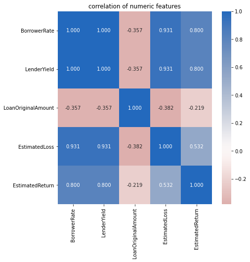

```python
# correlation plot
plt.figure(figsize = [7,7])
sb.heatmap(df[quan_vars].corr(), annot = True, fmt = '.3f',
           cmap = 'vlag_r', center = 0)

plt.subplots_adjust(top=0.9)
plt.title('correlation of numeric features')
plt.show();
```

Estimated Loss and Estimated Return are highly correlated with lenderYield and BrroweRate but they have negative corrolation with loan's amount

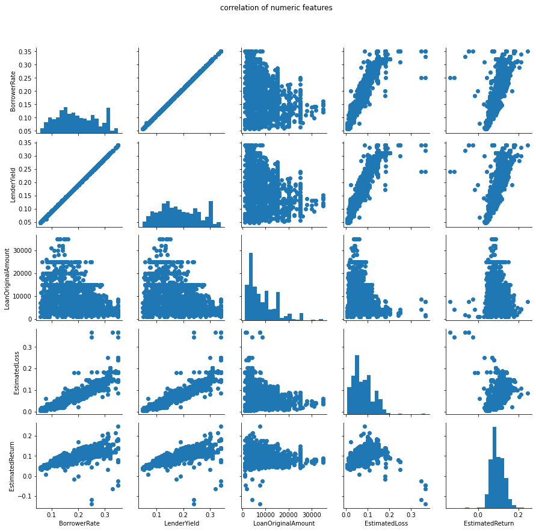

```python
# plot matrix: sample 20000
np.random.seed(45)
samples = np.random.choice(df.shape[0], 2000, replace = False)
df_samp = df.iloc[samples,:]

g = sb.PairGrid(data = df_samp, vars = quan_vars)
g = g.map_diag(plt.hist, bins = 20);
g.map_offdiag(plt.scatter)
plt.subplots_adjust(top=0.9)
g.fig.suptitle('correlation of numeric features');
```

the 'Borrowing Rate', and 'Lender Yield' are highly correlated with one another and have a linear relationship

[output not shown]

[output cut: 18 more lines]

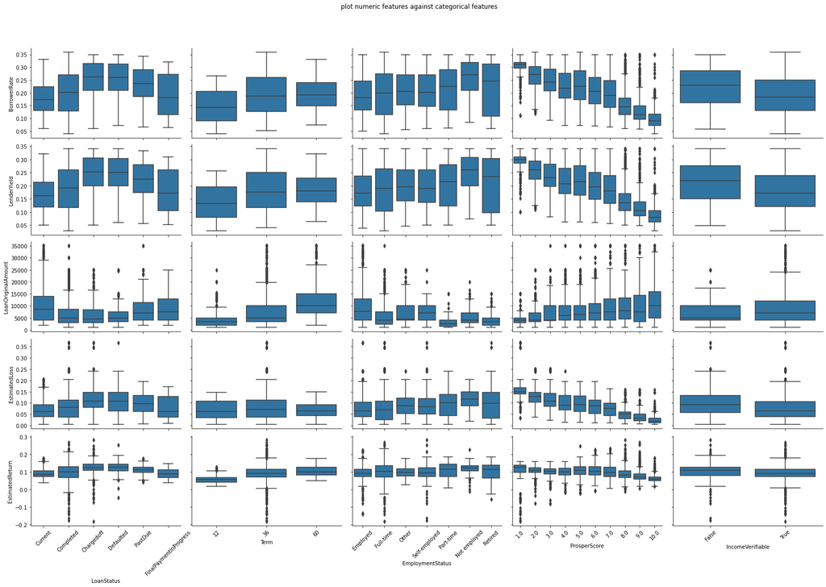

```python
# plot matrix of numeric features against categorical features.

np.random.seed(45)

samples = np.random.choice(df.shape[0], 20000, replace = False)
df_samp = df.iloc[samples,:]


def boxplot(x, y, **kwargs):

    plt.xticks(rotation = 45)
    sb.boxplot(x, y, color = color)


g = sb.PairGrid(data = df_samp, y_vars = quan_vars , x_vars = ['LoanStatus','Term' ,'EmploymentStatus','ProsperScore','IncomeVerifiable'],
                size = 3, aspect = 1.5)
g.map(boxplot)
plt.subplots_adjust(top=0.9)
g.fig.suptitle('plot numeric features against categorical features');
```

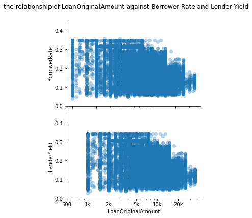

```python
def scatterplotbi(x, y, **kwargs):

    plt.scatter( x , y , alpha =0.3)
    plt.ylim((0, 0.45))
    plt.xscale('log')
    plt.xticks([500, 1e3, 2e3, 5e3, 1e4, 2e4], [500, '1k', '2k', '5k', '10k', '20k'])


g = sb.PairGrid(data = df_samp, y_vars = [ 'BorrowerRate','LenderYield'] , x_vars =  'LoanOriginalAmount' ,
                size = 3, aspect = 1.5)
g.map(scatterplotbi)
plt.subplots_adjust(top=0.9)
g.fig.suptitle('the relationship of LoanOriginalAmount against Borrower Rate and Lender Yield');
plt.show();
```

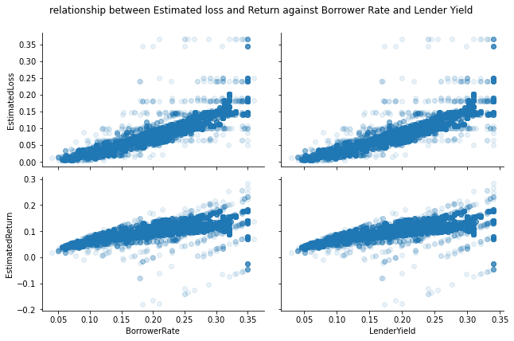

```python
def scatterplotbi(x, y, **kwargs):

    plt.scatter( x , y , alpha =0.1)

g = sb.PairGrid(data = df_samp, y_vars = [ 'EstimatedLoss','EstimatedReturn'] , x_vars =   [ 'BorrowerRate','LenderYield'] ,
                size = 3, aspect = 1.5)
g.map(scatterplotbi)
plt.subplots_adjust(top=0.9)
g.fig.suptitle('relationship between Estimated loss and Return against Borrower Rate and Lender Yield');
plt.show();
```

i just look at relationship between all interesting features to make decision on which one i will use in Multivariate Exploration

## Multivariate Exploration

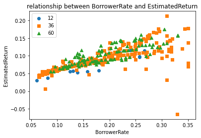

```python
cat_markers = [[12, 'o'],
               [36, 's'],
               [60,'^']]

np.random.seed(45)

samples = np.random.choice(df.shape[0], 500, replace = False)
df_samp = df.iloc[samples,:]

for cat, marker in cat_markers:
    df_cat = df_samp [df_samp ['Term'] == cat]
    plt.scatter(data = df_cat, x ='BorrowerRate', y = 'EstimatedReturn' , marker = marker)

plt.xlabel('BorrowerRate')
plt.ylabel('EstimatedReturn')
plt.title('relationship between BorrowerRate and EstimatedReturn')
plt.legend([12,36,60]);
```

there is linear relation between 'Borrower Rate' and 'Estimated Return' and types of Term is distrip on the line of this relation

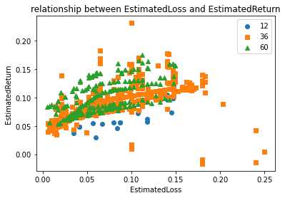

```python
cat_markers = [[12, 'o'],
               [36, 's'],
               [60,'^']]

np.random.seed(0)

samples = np.random.choice(df.shape[0], 1000, replace = False)
df_samp = df.iloc[samples,:]

for cat, marker in cat_markers:
    df_cat = df_samp [df_samp ['Term'] == cat]
    plt.scatter(data = df_cat, x ='EstimatedLoss', y = 'EstimatedReturn' , marker = marker)
plt.xlabel('EstimatedLoss')
plt.ylabel('EstimatedReturn')
plt.title('relationship between EstimatedLoss and EstimatedReturn')
plt.legend([12,36,60]);
```

all Estimated Loss values after 0.15 are 36 month in term

```python
# compute the logarithm of numbers to make multivariate plotting easier
def log_trans(x, inverse = False):

    if not inverse:
        return np.log10(x)
    else:
        return np.power(10, x)
```

```python
np.log(df.LoanOriginalAmount.describe())
```

```
count    10.977448
mean      9.045849
std       8.714533
min       6.907755
25%       8.294050
50%       8.853665
75%       9.392662
max      10.463103
Name: LoanOriginalAmount, dtype: float64
```

```python
def hist2dgrid(x, y,log = False ,**kwargs):

    palette = kwargs.pop('color')

    if log:
        bins_x = log_trans(np.arange(log_trans(df.LoanOriginalAmount.min()), log_trans(df.LoanOriginalAmount.max())+0.1,0.1),True)
        bins_y = np.arange(0.03,0.34+0.02, 0.02)
        plt.hist2d(x, y, bins = [bins_x, bins_y], cmap = palette, cmin = 0.5)
        plt.xscale('log')
        plt.xticks([1e3, 2e3, 5e3, 1e4, 2e4 ,3e4],[ '1k', '2k', '5k', '10k', '20k','30k'])

    else:
        bins_x = np.arange(0.03,0.34+0.02, 0.02)
        bins_y = np.arange(0,0.28+0.02, 0.02)
        plt.hist2d(x, y, bins = [bins_x, bins_y], cmap = palette, cmin = 0.5)
```

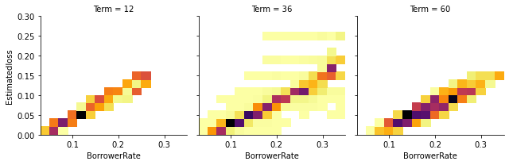

```python
g = sb.FacetGrid(data = df, col = 'Term', col_wrap = 3, size = 3)
g.map(hist2dgrid, 'BorrowerRate', 'EstimatedLoss'  , color = 'inferno_r')
g.set_xlabels('BorrowerRate')
g.set_ylabels('Estimatedloss');
```

36 month term has Estimated Loss high rang but most of them in same small rang of others

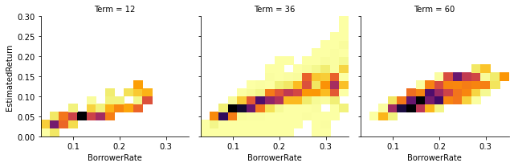

```python
g = sb.FacetGrid(data = df, col = 'Term', col_wrap = 3, size = 3)
g.map(hist2dgrid, 'BorrowerRate', 'EstimatedReturn' , color = 'inferno_r')
g.set_xlabels('BorrowerRate')
g.set_ylabels('EstimatedReturn');
```

36 month term has Estimated Return high rang but most of them in same small rang of others

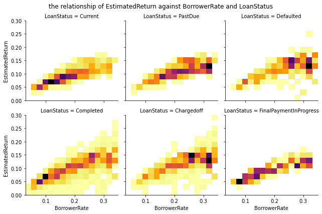

```python
g = sb.FacetGrid(data = df, col = 'LoanStatus', col_wrap = 3, size = 3)
g.map(hist2dgrid, 'BorrowerRate', 'EstimatedReturn'  , color = 'inferno_r')
g.set_xlabels('BorrowerRate')
g.set_ylabels('EstimatedReturn')
plt.subplots_adjust(top=0.9)
g.fig.suptitle('the relationship of EstimatedReturn against BorrowerRate and LoanStatus');
```